# smoker

Here, we will be discovering the relation between age and charges.  
The following graph is the age distribution of the whole dataset.

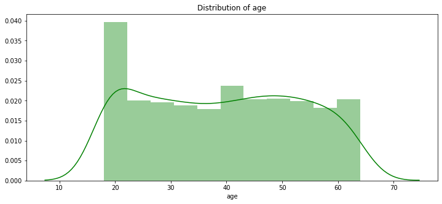

```python
pl.figure(figsize=(12,5))
pl.title("Distribution of age")
ax = sns.distplot(data["age"], color = 'g')
```

Then, we run a catplot hoping to find any clue in the age distribution with smoking habits. However, the result shows age won’t affect the distribution of smokers. In any age, there are more non-smoker than smokers, and male smokers than female smokers.

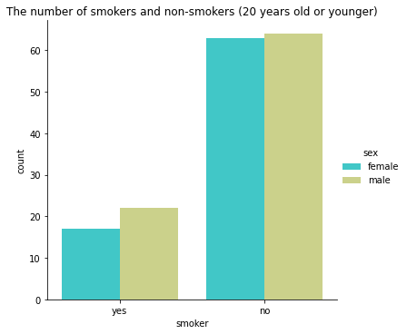

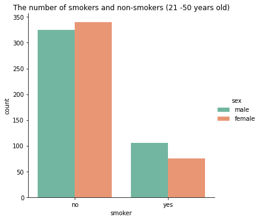

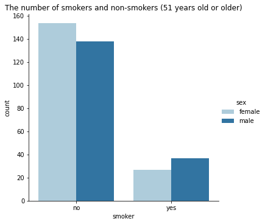

```python
#distribution of 20 or younger patients by gender and smoking habit
sns.catplot(x="smoker", kind="count",hue = 'sex', palette="rainbow", data=data1[(data.age <= 20)])
pl.title("The number of smokers and non-smokers (20 years old or younger)")

#distribution of 21-50 or younger patients by gender and smoking habit
greaterthan20 = data1['age'] >= 20
lessthan50 = data1['age'] <= 50
sns.catplot(x="smoker", kind="count",hue = 'sex', palette="Set2", data=data1[greaterthan20 & lessthan50])
pl.title("The number of smokers and non-smokers (21 -50 years old)")

#distribution of 51+ years old patients by gender and smoking habit
sns.catplot(x="smoker", kind="count",hue = 'sex', palette="Paired", data=data1[(data.age >= 51)])
pl.title("The number of smokers and non-smokers (51 years old or older)")
```

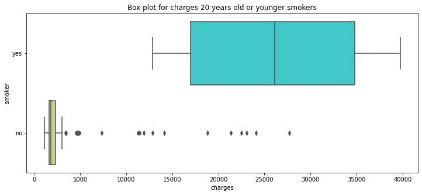

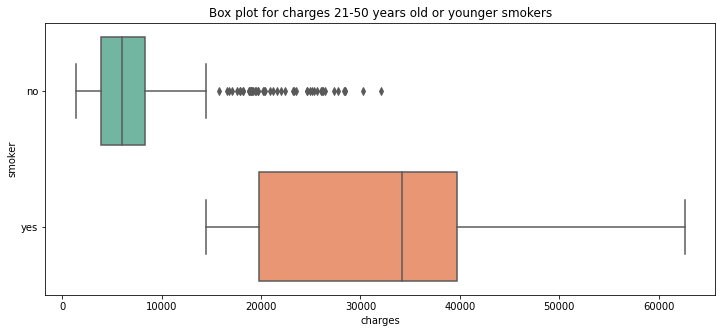

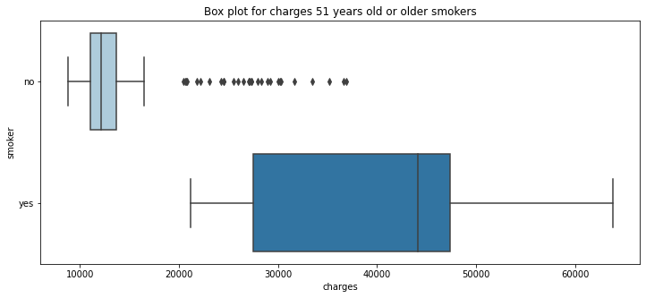

```python
# boxplot for 20 years old or younger, by smoking habit
pl.figure(figsize=(12,5))
pl.title("Box plot for charges 20 years old or younger smokers")
sns.boxplot(y="smoker", x="charges", data = data1[(data.age <= 20)] , orient="h", palette = 'rainbow')

# boxplot for 21-50 years old, by smoking habit
pl.figure(figsize=(12,5))
pl.title("Box plot for charges 21-50 years old or younger smokers")
sns.boxplot(y="smoker", x="charges", data = data1[greaterthan20 & lessthan50] , orient="h", palette = 'Set2')

# boxplot fpr 51 years old or older, by smoking habit
pl.figure(figsize=(12,5))
pl.title("Box plot for charges 51 years old or older smokers")
sns.boxplot(y="smoker", x="charges", data = data1[(data.age >= 51)] , orient="h", palette = 'Paired')
```

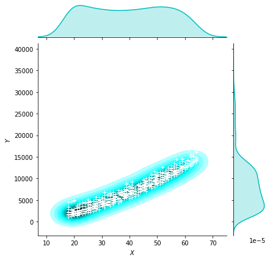

```python
g = sns.jointplot(x="age", y="charges", data = data[(data.smoker == 0)],kind="kde", color="c")
g.plot_joint(pl.scatter, c="w", s=30, linewidth=1, marker="+")
g.ax_joint.collections[0].set_alpha(0)
g.set_axis_labels("$X$", "$Y$")
ax.set_title('Distribution of charges and age for non-smokers')
```

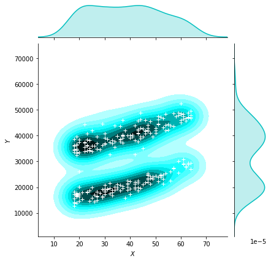

```python
g = sns.jointplot(x="age", y="charges", data = data[(data.smoker == 1)],kind="kde", color="c")
g.plot_joint(pl.scatter, c="w", s=30, linewidth=1, marker="+")
g.ax_joint.collections[0].set_alpha(0)
g.set_axis_labels("$X$", "$Y$")
ax.set_title('Distribution of charges and age for smokers')
```

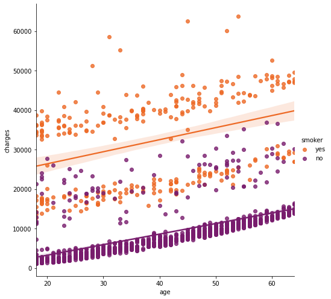

```python
sns.lmplot(x="age", y="charges", hue="smoker", data=data1, palette = 'inferno_r', size = 7)
ax.set_title('Smokers and non-smokers')
```

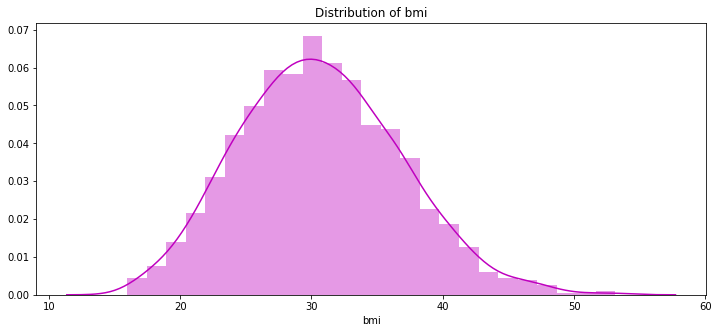

```python
pl.figure(figsize=(12,5))
pl.title("Distribution of bmi")
ax = sns.distplot(data["bmi"], color = 'm')
```

Now what’s left is the bmi. Will body shape have anything to with charges? We first run a distribution plot of the entire data set. And the mode of BMI in patients is 30. With a value equal to 30 starts obesity and this symmetrical figure. We know that about half of the patients in our data set are obese or even extremely obese

[figure not shown]

In our common sense, obese will induce all kinds of diseases. So we want to see if obesity affect charges. And the answer is YES! From the distribution plot we see that for patients with BMI greater than 30, some of them are paying much more than those who have a bmi less than 30.

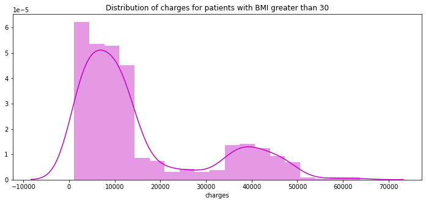

```python
pl.figure(figsize=(12,5))
pl.title("Distribution of charges for patients with BMI greater than 30")
ax = sns.distplot(data[data.bmi >= 30]['charges'], color = 'm')
```

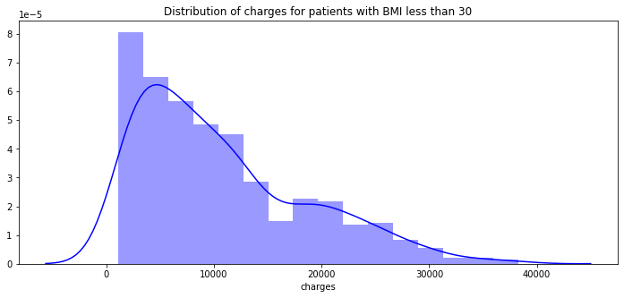

```python
pl.figure(figsize=(12,5))
pl.title("Distribution of charges for patients with BMI less than 30")
ax = sns.distplot(data[(data.bmi < 30)]['charges'], color = 'b')
```

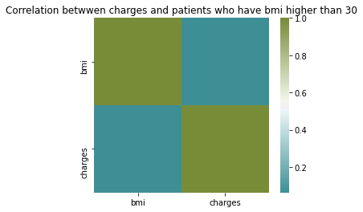

```python
#data['bmi']corr.data['charges']
data3 = data[data.bmi >= 30][['bmi','charges']]
corr = data3.corr(method='pearson')
f, ax = pl.subplots(figsize=(5, 4))
pl.title("Correlation betwwen charges and patients who have bmi higher than 30")
cmap = sns.diverging_palette(200, 100, s=80, l=55, n=9,as_cmap=True)
sns.heatmap(corr, cmap=cmap, square=True, ax=ax)
```

Our last guess is , will charges increase as patient’s BMI goes up? So we run a correlation between charges and the bmi of patients who have BMI higher than 30. The answer is no. There’s barely any connection between the BMI of obese patient and their medical cost. But what’s for sure is that some of them do pay a lot more than patients who are having a healthier body shape.

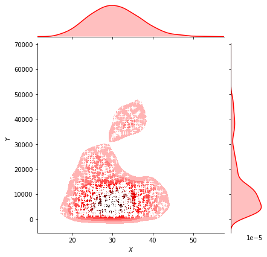

```python
g = sns.jointplot(x="bmi", y="charges", data = data,kind="kde", color="r")
g.plot_joint(pl.scatter, c="w", s=30, linewidth=1, marker="+")
g.ax_joint.collections[0].set_alpha(0)
g.set_axis_labels("$X$", "$Y$")
ax.set_title('Distribution of bmi and charges')
```

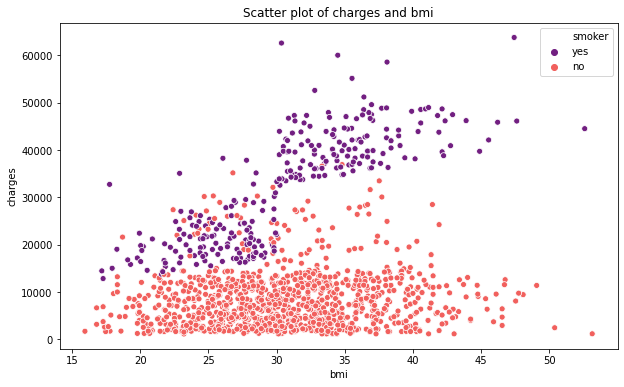

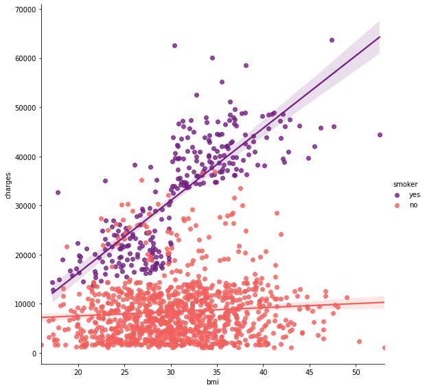

```python
pl.figure(figsize=(10,6))
ax = sns.scatterplot(x='bmi',y='charges',data=data1,palette='magma',hue='smoker')
ax.set_title('Scatter plot of charges and bmi')

sns.lmplot(x="bmi", y="charges", hue="smoker", data=data1, palette = 'magma', size = 8)
```

Let's pay attention to children. First, let's see how many children our patients have.

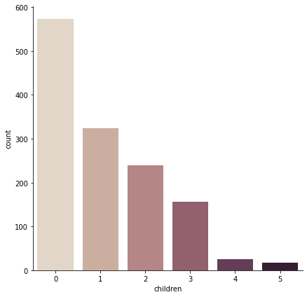

```python
sns.catplot(x="children", kind="count", palette="ch:.25", data=data, size = 6)
```

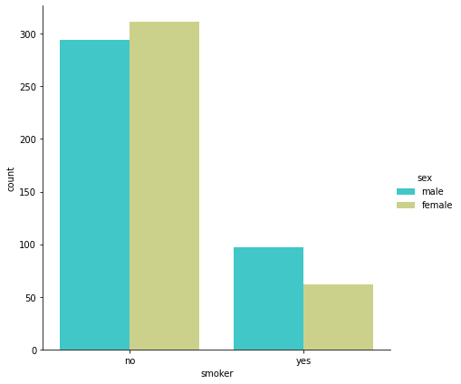

```python
sns.catplot(x="smoker", kind="count", palette="rainbow",hue = "sex",
            data=data1[(data.children > 0)], size = 6)
ax.set_title('Smokers and non-smokers who have childrens')
```

Now we will be fitting the data to several predictions models:

1. Linear Regression
2. Decision Tree
3. Polynomial Regression
4. Random Forest

We will compute the R^2 score and find out what are the best algorithms for our insurance charges prediction

```python
from sklearn.linear_model import LinearRegression
from sklearn.tree import DecisionTreeRegressor
from sklearn.model_selection import train_test_split
from sklearn.preprocessing import PolynomialFeatures
from sklearn.metrics import r2_score,mean_squared_error
from sklearn.ensemble import RandomForestRegressor
```

Since the correlation between region and charges is very close to zero, we will be eliminating region from the input features.

```python
X = data.drop(['charges','region'], axis = 1)
Y = data.charges

x_train,x_test,y_train,y_test = train_test_split(X,Y, random_state = 0)
lr = LinearRegression().fit(x_train,y_train)

y_train_pred = lr.predict(x_train)
y_test_pred = lr.predict(x_test)

#coefficient of determination R^2 of the prediction
print(lr.score(x_test,y_test))
```

```
0.7952171980481992
```

```python
#decision tree with default parameters
tree = DecisionTreeRegressor(random_state=0)
decision_tree = tree.fit(x_train, y_train)

print("There are " + str(decision_tree.get_n_leaves()) + " leaf nodes with the default decision tree")
y_train_pred_tree = decision_tree.predict(x_train)
y_test_pred_tree = decision_tree.predict(x_test)
#R^2 score for default decision tree
print("R^score for " + str(decision_tree.get_n_leaves()) + " leaf nodes decision tree (default decision tree): " + str(decision_tree.score(x_test, y_test)))

#20 leaf nodes decision tree
tree = DecisionTreeRegressor(max_leaf_nodes = 20, random_state=0)
decision_tree = tree.fit(x_train, y_train)

y_train_pred_tree = decision_tree.predict(x_train)
y_test_pred_tree = decision_tree.predict(x_test)
#R^2 score for 20 leaf node decision tree
print("R^score for " + str(decision_tree.get_n_leaves()) + " leaf nodes decision tree: " + str(decision_tree.score(x_test, y_test)))

#5 leaf nodes decision tree
tree = DecisionTreeRegressor(max_leaf_nodes = 5, random_state=0)
decision_tree = tree.fit(x_train, y_train)

y_train_pred_tree = decision_tree.predict(x_train)
y_test_pred_tree = decision_tree.predict(x_test)
#R^2 score for 5 leaf node decision tree
print("R^score for " + str(decision_tree.get_n_leaves()) + " leaf nodes decision tree: " + str(decision_tree.score(x_test, y_test)))

#10 leaf nodes decision tree
tree = DecisionTreeRegressor(max_leaf_nodes = 10, random_state=0)
decision_tree = tree.fit(x_train, y_train)

y_train_pred_tree = decision_tree.predict(x_train)
y_test_pred_tree = decision_tree.predict(x_test)
#R^2 score for 10 leaf node decision tree
print("R^score for " + str(decision_tree.get_n_leaves()) + " leaf nodes decision tree: " + str(decision_tree.score(x_test, y_test)))

# Explore the decision tree structure for 10 leaf nodes decision tree
print("Feature importance \n age :" + str(decision_tree.feature_importances_[0]) + "; sex :", str(decision_tree.feature_importances_[1]) + "; bmi :" + str(decision_tree.feature_importances_[2]) + "; children :" + str(decision_tree.feature_importances_[3]) + "; smoker :" + str(decision_tree.feature_importances_[4]))
print(decision_tree.get_n_leaves())
print(decision_tree.get_depth())
```

```
There are 1002 leaf nodes with the default decision tree
R^score for 1002 leaf nodes decision tree (default decision tree): 0.7066938232389572
R^score for 20 leaf nodes decision tree: 0.8601964345758669
R^score for 5 leaf nodes decision tree: 0.8634565548728383
R^score for 10 leaf nodes decision tree: 0.8820138096747816
Feature importance
 age :0.11742942258810696; sex : 0.0; bmi :0.16707901018667018; children :0.0037307434872472576; smoker :0.7117608237379757
10
4
```

We have tried different number of nodes for the decision tree and find that 10 nodes is the best parameter for this decision tree, resulting in a R^2 score of 0.882

[figure not shown]

```python
quad = PolynomialFeatures (degree = 4)
x_quad = quad.fit_transform(X)

X_train,X_test,Y_train,Y_test = train_test_split(x_quad,Y, random_state = 0)

plr = LinearRegression().fit(X_train,Y_train)

Y_train_pred = plr.predict(X_train)
Y_test_pred = plr.predict(X_test)

print("R^2 score for 4 degree polynomial regression: " + str(plr.score(X_test,Y_test)))

quad = PolynomialFeatures (degree = 3)
x_quad = quad.fit_transform(X)

X_train,X_test,Y_train,Y_test = train_test_split(x_quad,Y, random_state = 0)

plr = LinearRegression().fit(X_train,Y_train)

Y_train_pred = plr.predict(X_train)
Y_test_pred = plr.predict(X_test)

print("R^2 score for 3 degree polynomial regression: " + str(plr.score(X_test,Y_test)))

quad = PolynomialFeatures (degree = 2)
x_quad = quad.fit_transform(X)

X_train,X_test,Y_train,Y_test = train_test_split(x_quad,Y, random_state = 0)

plr = LinearRegression().fit(X_train,Y_train)

Y_train_pred = plr.predict(X_train)
Y_test_pred = plr.predict(X_test)

print("R^2 score for 2 degree polynomial regression: " + str(plr.score(X_test,Y_test)))
```

```
R^2 score for 4 degree polynomial regression: 0.8795123459663741
R^2 score for 3 degree polynomial regression: 0.8810168906745303
R^2 score for 2 degree polynomial regression: 0.8849197344147228
```

2 degree polynomial regression appears to best fit our test data set.  
Finally, we will be running random forest regressor to predict the charges.

```python
forest = RandomForestRegressor(n_estimators = 10,
                              criterion = 'mse',
                              random_state = 1,
                              n_jobs = -1)
forest.fit(x_train,y_train)
forest_train_pred = forest.predict(x_train)
forest_test_pred = forest.predict(x_test)

print("Random Forest with 10 trees: ")
print('MSE train data: %.3f, MSE test data: %.3f' % (
mean_squared_error(y_train,forest_train_pred),
mean_squared_error(y_test,forest_test_pred)))
print('R2 train data: %.3f, R2 test data: %.3f' % (
r2_score(y_train,forest_train_pred),
r2_score(y_test,forest_test_pred)))

forest = RandomForestRegressor(n_estimators = 40,
                              criterion = 'mse',
                              random_state = 1,
                              n_jobs = -1)
forest.fit(x_train,y_train)
forest_train_pred = forest.predict(x_train)
forest_test_pred = forest.predict(x_test)

print("Random Forest with 40 trees: ")
print('MSE train data: %.3f, MSE test data: %.3f' % (
mean_squared_error(y_train,forest_train_pred),
mean_squared_error(y_test,forest_test_pred)))
print('R2 train data: %.3f, R2 test data: %.3f' % (
r2_score(y_train,forest_train_pred),
r2_score(y_test,forest_test_pred)))

forest = RandomForestRegressor(n_estimators = 100,
                              criterion = 'mse',
                              random_state = 1,
                              n_jobs = -1)
forest.fit(x_train,y_train)
forest_train_pred = forest.predict(x_train)
forest_test_pred = forest.predict(x_test)

print("Random Forest with 100 trees: ")
print('MSE train data: %.3f, MSE test data: %.3f' % (
mean_squared_error(y_train,forest_train_pred),
mean_squared_error(y_test,forest_test_pred)))
print('R2 train data: %.3f, R2 test data: %.3f' % (
r2_score(y_train,forest_train_pred),
r2_score(y_test,forest_test_pred)))

forest = RandomForestRegressor(n_estimators = 200,
                              criterion = 'mse',
                              random_state = 1,
                              n_jobs = -1)
forest.fit(x_train,y_train)
forest_train_pred = forest.predict(x_train)
forest_test_pred = forest.predict(x_test)

print("Random Forest with 200 trees: ")
print('MSE train data: %.3f, MSE test data: %.3f' % (
mean_squared_error(y_train,forest_train_pred),
mean_squared_error(y_test,forest_test_pred)))
print('R2 train data: %.3f, R2 test data: %.3f' % (
r2_score(y_train,forest_train_pred),
r2_score(y_test,forest_test_pred)))

forest = RandomForestRegressor(n_estimators = 300,
                              criterion = 'mse',
                              random_state = 1,
                              n_jobs = -1)
forest.fit(x_train,y_train)
forest_train_pred = forest.predict(x_train)
forest_test_pred = forest.predict(x_test)

print("Random Forest with 300 trees: ")
print('MSE train data: %.3f, MSE test data: %.3f' % (
mean_squared_error(y_train,forest_train_pred),
mean_squared_error(y_test,forest_test_pred)))
print('R2 train data: %.3f, R2 test data: %.3f' % (
r2_score(y_train,forest_train_pred),
r2_score(y_test,forest_test_pred)))
```

```
Random Forest with 10 trees:
MSE train data: 4769185.792, MSE test data: 26499425.457
R2 train data: 0.967, R2 test data: 0.832
Random Forest with 40 trees:
MSE train data: 4079075.996, MSE test data: 21559984.654
R2 train data: 0.971, R2 test data: 0.863
Random Forest with 100 trees:
MSE train data: 3897597.810, MSE test data: 20762308.626
R2 train data: 0.973, R2 test data: 0.868
Random Forest with 200 trees:
MSE train data: 3807717.255, MSE test data: 20679994.815
R2 train data: 0.973, R2 test data: 0.869
Random Forest with 300 trees:
MSE train data: 3705309.607, MSE test data: 20872403.754
R2 train data: 0.974, R2 test data: 0.867
```

[figure not shown]

Refering to our experiments above, we believe the company should use the 2 degree polynomial regression, 10 leaf nodes decision tree, and random forest regressor we have developed above to predict their customers charges base on the customers gender, age, bmi, smoking habit, and number of children. Using 3 different models allow the company to diversify risks of relying on only one model.